# Notebook

Last modified

Sep, 2025

06

10:45:49 AM

Statistics, Probability and Noise

signal; signal domain; signal types; mean; std;

## References

1. [DSP Guide: Chapter 2](http://www.dspguide.com/ch2/1.htm)

## Signal

A **signal** is a description on how one parameter depends on another parameter. The former is referred to as **dependent variable/parameter** while the latter **independent variable/parameter**. One should note that the independent variable either goes from $-\infty \rightarrow +\infty$ or assumed so in case of a finite signal.

E.g., $y = sin(t)$ --- where, $y$ is dependent variable and $t$ is independent variable.

Alternate names for the variables:

- **Dependent variable**: amplitude, y-axis, dependent variable, range, ordinate.
- **Independent variable**: x-axis, independent variable, domain, abscissa.

For any point on the x-axis, we can find a corresponding value along the y-axis but vice-versa is not true.

## Domain of a Signal

x-axis or the independent variable determines the domain of a signal. Whatever the x-axis represents physically is said to be the domain of the signal. The most common types are **time-domain**, **spatial-domain**, **frequency-domain** where the x-axis represents either time, location, frequency respectively.

For convenience, I will assume the signal to be time-domain signal.

## Types of Signal

Based on the parameters, we can classify signal into different types:

| Independent Parameter | Dependent Parameter | Signal Type | Example |
| --- | --- | --- | --- |
| Continuous (all real *t*) | Continuous (real-valued) | Continuous-Time, Continuous-Valued | x(t) = sin(t) |
| Continuous | Discrete / Quantized | Continuous-Time, Discrete-Valued | Digital clock display (still defined for all t) |
| Discrete (integer steps *n*) | Continuous | Discrete-Time, Continuous-Valued | x[n] = sin(nT) |
| Discrete | Discrete / Quantized | Discrete-Time, Discrete-Valued (Digital Signal) | 16-bit PCM audio samples |

[figure not shown]

## Mean of a signal

Let's say we have a discrete-time signal $y[n]$ and we would like to find out an single aggregated value $\alpha$ which represents the signal well.

We first need to figure out what we mean by a better representation. We devise a loss/error function $E(\alpha)$ that we need to minimise. One popular choice of $E$ is squared error given by:

$E(\alpha) = \sum_{n=0}^{N-1} (y[n] - \alpha)^2$

In order to find the optimal $\alpha$, we set

$\frac{dE(\alpha)}{d\alpha} = 0 $

$\implies \frac{d}{d\alpha}\sum_{n=0}^{N-1} (y[n] - \alpha)^2 = 0$

$\implies \frac{d}{d\alpha} (y[0] - \alpha)^2 + \frac{d}{d\alpha} (y[1] - \alpha)^2 + ... + \frac{d}{d\alpha} (y[N-1] - \alpha)^2 = 0$

$\implies -2 (y[0] - \alpha) + -2 (y[1] - \alpha) + ... + -2 (y[N-1] - \alpha) = 0$

$\implies y[0] + y[1] + ... + y[n-1] - N\alpha = 0$

$\implies \alpha = \frac{1}{N} (y[0] + y[1] + ... + y[N-1])$

$\implies \alpha = \frac{1}{N} \sum_{n=0}^{N-1}y[n]$

This $\alpha$ is the mean of the signal $y[n]$. Mean is denoted by $\mu$ and is given by:

$\mu = \frac{1}{N}\sum_{n=0}^{N-1} y[n]$

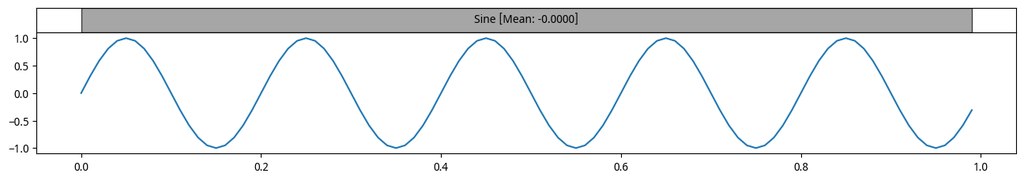

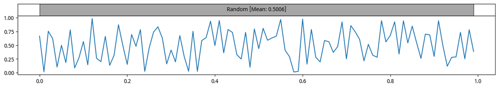

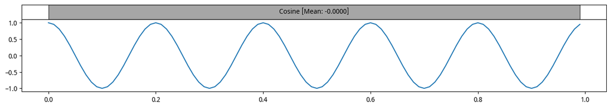

Since a signal encapsulates behaviour of a system so analsing the signal becomes really important to understand the system. One can hypothetically analyse signal manually, by analysing values one-by-one but we do have computers to handle that tedious task of performing operations that too with better accuracy, speed and efficiency.

But there is a catch, in order to use *computers*, we have to store the signal into **memory** that computers can access. Since, signals that we deal with are continuous, there is no way to store that infinite amount of information in computer. There are various **quantization** that we have to perform to allow computers to store signal. Signal thus stored in computer is referred to as **digital signal**.

## Analog to Digital Conversion

The process of converting an analog/continuous signal into digital/discrete signal is called **ADC**. It stands for **Analog to Digital Conversion**. This process involves **quantization** of the signal so that they can be stored in computer.

### Sampling

Since we have limited memory to store signal in computer, we perform *sampling* which means that we only collect values of the analog signal at certain timepoints often equally spaced by say $T$ sec which is known as **sampling period** of the signal. The inverse of $T$ is called **sampling frequency** $f_s = \frac{1}{T}$ hz

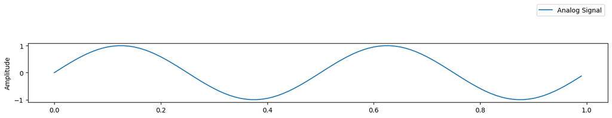

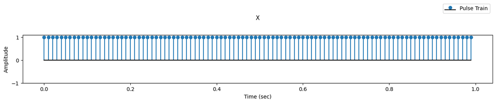

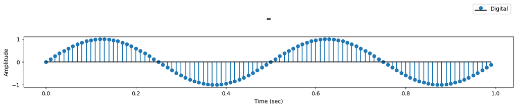

### Amplitude Quantization

All the values of the analog signal are rounded to the nearest bin computed as per the bit-depth.

The range of numbers for a given bit depth depends on the datatype used to store the values.

## SQNR

Due to this amplitude quantization, we get **quantisation error** leading to **quantization noise** This is often reported as sound-to-quantization-noise-ratio aka $SQNR$.

$SQNR \propto n $